# Risk Factor Analysis

## Outcome Variable

**Outcome Variable:** whz

## Predictor Variables

**Intervention Variable:** exclfeed6

**Adjustment Set:**

unadjusted

## Stratifying Variables

The analysis was stratified on these variable(s):

- agecat
- studyid
- country

## Data Summary

| agecat | studyid | country | exclfeed6 | n_cell | n |
| --- | --- | --- | --- | --- | --- |
| Birth | ki0047075b-MAL-ED | BANGLADESH | 1 | 29 | 194 |
| Birth | ki0047075b-MAL-ED | BANGLADESH | 0 | 165 | 194 |
| Birth | ki0047075b-MAL-ED | BRAZIL | 1 | 1 | 57 |
| Birth | ki0047075b-MAL-ED | BRAZIL | 0 | 56 | 57 |
| Birth | ki0047075b-MAL-ED | INDIA | 1 | 1 | 37 |
| Birth | ki0047075b-MAL-ED | INDIA | 0 | 36 | 37 |
| Birth | ki0047075b-MAL-ED | NEPAL | 1 | 2 | 23 |
| Birth | ki0047075b-MAL-ED | NEPAL | 0 | 21 | 23 |
| Birth | ki0047075b-MAL-ED | PERU | 1 | 2 | 208 |
| Birth | ki0047075b-MAL-ED | PERU | 0 | 206 | 208 |
| Birth | ki0047075b-MAL-ED | SOUTH AFRICA | 1 | 0 | 90 |
| Birth | ki0047075b-MAL-ED | SOUTH AFRICA | 0 | 90 | 90 |
| Birth | ki0047075b-MAL-ED | TANZANIA, UNITED REPUBLIC OF | 1 | 0 | 105 |
| Birth | ki0047075b-MAL-ED | TANZANIA, UNITED REPUBLIC OF | 0 | 105 | 105 |
| Birth | ki1000108-CMC-V-BCS-2002 | INDIA | 1 | 7 | 7 |
| Birth | ki1000108-CMC-V-BCS-2002 | INDIA | 0 | 0 | 7 |
| Birth | ki1000108-IRC | INDIA | 1 | 0 | 12 |
| Birth | ki1000108-IRC | INDIA | 0 | 12 | 12 |
| Birth | ki1000109-EE | PAKISTAN | 1 | 24 | 28 |
| Birth | ki1000109-EE | PAKISTAN | 0 | 4 | 28 |
| Birth | ki1000304b-SAS-CompFeed | INDIA | 1 | 310 | 325 |
| Birth | ki1000304b-SAS-CompFeed | INDIA | 0 | 15 | 325 |
| Birth | ki1017093b-PROVIDE | BANGLADESH | 1 | 155 | 532 |
| Birth | ki1017093b-PROVIDE | BANGLADESH | 0 | 377 | 532 |
| Birth | ki1101329-Keneba | GAMBIA | 1 | 450 | 1327 |
| Birth | ki1101329-Keneba | GAMBIA | 0 | 877 | 1327 |
| Birth | ki1113344-GMS-Nepal | NEPAL | 1 | 390 | 522 |
| Birth | ki1113344-GMS-Nepal | NEPAL | 0 | 132 | 522 |
| Birth | kiGH5241-JiVitA-3 | BANGLADESH | 1 | 8381 | 10744 |
| Birth | kiGH5241-JiVitA-3 | BANGLADESH | 0 | 2363 | 10744 |

[output cut: 70 more lines]

The following strata were considered:

- agecat: 24 months, studyid: ki0047075b-MAL-ED, country: BANGLADESH
- agecat: 24 months, studyid: ki0047075b-MAL-ED, country: BRAZIL
- agecat: 24 months, studyid: ki0047075b-MAL-ED, country: INDIA
- agecat: 24 months, studyid: ki0047075b-MAL-ED, country: NEPAL
- agecat: 24 months, studyid: ki0047075b-MAL-ED, country: PERU
- agecat: 24 months, studyid: ki0047075b-MAL-ED, country: SOUTH AFRICA
- agecat: 24 months, studyid: ki0047075b-MAL-ED, country: TANZANIA, UNITED REPUBLIC OF
- agecat: 24 months, studyid: ki1000108-CMC-V-BCS-2002, country: INDIA
- agecat: 24 months, studyid: ki1000108-IRC, country: INDIA
- agecat: 24 months, studyid: ki1000109-EE, country: PAKISTAN
- agecat: 24 months, studyid: ki1017093b-PROVIDE, country: BANGLADESH
- agecat: 24 months, studyid: ki1101329-Keneba, country: GAMBIA
- agecat: 24 months, studyid: ki1113344-GMS-Nepal, country: NEPAL
- agecat: 24 months, studyid: ki1148112-LCNI-5, country: MALAWI
- agecat: 24 months, studyid: kiGH5241-JiVitA-3, country: BANGLADESH
- agecat: 24 months, studyid: kiGH5241-JiVitA-4, country: BANGLADESH
- agecat: 6 months, studyid: ki0047075b-MAL-ED, country: BANGLADESH
- agecat: 6 months, studyid: ki0047075b-MAL-ED, country: BRAZIL
- agecat: 6 months, studyid: ki0047075b-MAL-ED, country: INDIA
- agecat: 6 months, studyid: ki0047075b-MAL-ED, country: NEPAL
- agecat: 6 months, studyid: ki0047075b-MAL-ED, country: PERU
- agecat: 6 months, studyid: ki0047075b-MAL-ED, country: SOUTH AFRICA
- agecat: 6 months, studyid: ki0047075b-MAL-ED, country: TANZANIA, UNITED REPUBLIC OF
- agecat: 6 months, studyid: ki1000108-CMC-V-BCS-2002, country: INDIA
- agecat: 6 months, studyid: ki1000108-IRC, country: INDIA
- agecat: 6 months, studyid: ki1000109-EE, country: PAKISTAN
- agecat: 6 months, studyid: ki1000304b-SAS-CompFeed, country: INDIA
- agecat: 6 months, studyid: ki1000304b-SAS-FoodSuppl, country: INDIA
- agecat: 6 months, studyid: ki1017093b-PROVIDE, country: BANGLADESH
- agecat: 6 months, studyid: ki1101329-Keneba, country: GAMBIA
- agecat: 6 months, studyid: ki1113344-GMS-Nepal, country: NEPAL
- agecat: 6 months, studyid: ki1148112-LCNI-5, country: MALAWI
- agecat: 6 months, studyid: kiGH5241-JiVitA-3, country: BANGLADESH
- agecat: 6 months, studyid: kiGH5241-JiVitA-4, country: BANGLADESH
- agecat: Birth, studyid: ki0047075b-MAL-ED, country: BANGLADESH
- agecat: Birth, studyid: ki0047075b-MAL-ED, country: BRAZIL
- agecat: Birth, studyid: ki0047075b-MAL-ED, country: INDIA
- agecat: Birth, studyid: ki0047075b-MAL-ED, country: NEPAL
- agecat: Birth, studyid: ki0047075b-MAL-ED, country: PERU
- agecat: Birth, studyid: ki0047075b-MAL-ED, country: SOUTH AFRICA
- agecat: Birth, studyid: ki0047075b-MAL-ED, country: TANZANIA, UNITED REPUBLIC OF
- agecat: Birth, studyid: ki1000108-CMC-V-BCS-2002, country: INDIA
- agecat: Birth, studyid: ki1000108-IRC, country: INDIA
- agecat: Birth, studyid: ki1000109-EE, country: PAKISTAN
- agecat: Birth, studyid: ki1000304b-SAS-CompFeed, country: INDIA
- agecat: Birth, studyid: ki1017093b-PROVIDE, country: BANGLADESH
- agecat: Birth, studyid: ki1101329-Keneba, country: GAMBIA
- agecat: Birth, studyid: ki1113344-GMS-Nepal, country: NEPAL
- agecat: Birth, studyid: kiGH5241-JiVitA-3, country: BANGLADESH
- agecat: Birth, studyid: kiGH5241-JiVitA-4, country: BANGLADESH

### Dropped Strata

Some strata were dropped due to rare outcomes:

- agecat: Birth, studyid: ki0047075b-MAL-ED, country: BRAZIL
- agecat: Birth, studyid: ki0047075b-MAL-ED, country: INDIA
- agecat: Birth, studyid: ki0047075b-MAL-ED, country: NEPAL
- agecat: Birth, studyid: ki0047075b-MAL-ED, country: PERU
- agecat: Birth, studyid: ki0047075b-MAL-ED, country: SOUTH AFRICA
- agecat: Birth, studyid: ki0047075b-MAL-ED, country: TANZANIA, UNITED REPUBLIC OF
- agecat: Birth, studyid: ki1000108-CMC-V-BCS-2002, country: INDIA
- agecat: Birth, studyid: ki1000108-IRC, country: INDIA
- agecat: Birth, studyid: ki1000109-EE, country: PAKISTAN
- agecat: 6 months, studyid: ki0047075b-MAL-ED, country: INDIA
- agecat: 6 months, studyid: ki0047075b-MAL-ED, country: SOUTH AFRICA
- agecat: 6 months, studyid: ki0047075b-MAL-ED, country: TANZANIA, UNITED REPUBLIC OF
- agecat: 6 months, studyid: ki1000108-CMC-V-BCS-2002, country: INDIA
- agecat: 6 months, studyid: ki1000108-IRC, country: INDIA
- agecat: 6 months, studyid: ki1000304b-SAS-FoodSuppl, country: INDIA
- agecat: 24 months, studyid: ki0047075b-MAL-ED, country: INDIA
- agecat: 24 months, studyid: ki0047075b-MAL-ED, country: PERU
- agecat: 24 months, studyid: ki0047075b-MAL-ED, country: SOUTH AFRICA
- agecat: 24 months, studyid: ki0047075b-MAL-ED, country: TANZANIA, UNITED REPUBLIC OF
- agecat: 24 months, studyid: ki1000108-CMC-V-BCS-2002, country: INDIA
- agecat: 24 months, studyid: ki1000108-IRC, country: INDIA
- agecat: 24 months, studyid: ki1000109-EE, country: PAKISTAN

## Methods Detail

We’re interested in the causal parameters $E[Y_a]$ for all values of $a \in \mathcal{A}$. These parameters represent the mean outcome if, possibly contrary to fact, we intervened to set all units to have $A=a$. Under the randomization and positivity assumptions, these are identified by the statistical parameters $\psi_a=E_W[E_{Y|A,W}(Y|A=a,W)]$. In addition, we’re interested in the mean of $Y$, $E[Y]$ under no intervention (the observed mean). We will estimate these parameters by using SuperLearner to fit the relevant likelihood factors – $E_{Y|A,W}(Y|A=a,W)$ and $p(A=a|W)$, and then updating our likelihood fit using a joint TMLE.

For unadjusted analyses ($W=\{\}$), initial likelihoods were estimated using Lrnr_glm to estimate the simple $E(Y|A)$ and Lrnr_mean to estimate $p(A)$. For adjusted analyses, a small library containing Lrnr_glmnet, Lrnr_xgboost, and Lrnr_mean was used.

Having estimated these parameters, we will then use the delta method to estimate relative risks and attributable risks relative to a prespecified baseline level of $A$.

# Results Detail

## Results Plots

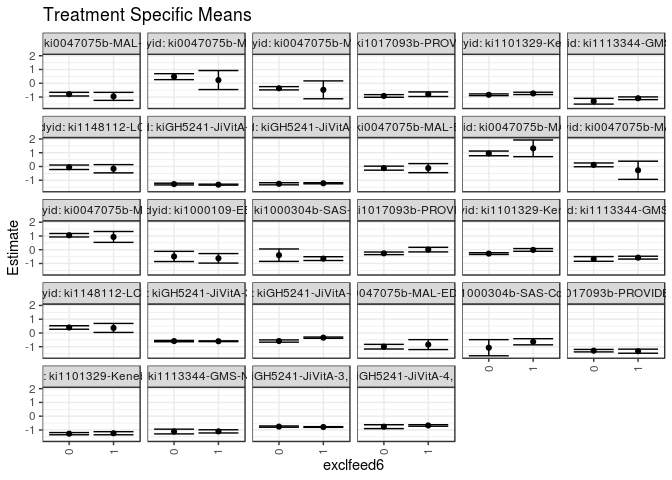

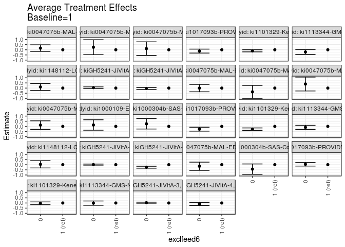

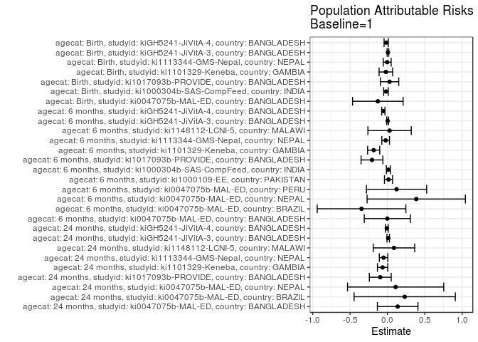

## Results Table

### Parameter: TSM

| agecat | studyid | country | intervention_level | baseline_level | estimate | ci_lower | ci_upper |
| --- | --- | --- | --- | --- | --- | --- | --- |
| Birth | ki0047075b-MAL-ED | BANGLADESH | 1 | NA | -0.8468966 | -1.2072911 | -0.4865020 |
| Birth | ki0047075b-MAL-ED | BANGLADESH | 0 | NA | -0.9981818 | -1.1664833 | -0.8298803 |
| Birth | ki1000304b-SAS-CompFeed | INDIA | 1 | NA | -0.6397097 | -0.8621395 | -0.4172798 |
| Birth | ki1000304b-SAS-CompFeed | INDIA | 0 | NA | -1.0713333 | -1.6580583 | -0.4846084 |
| Birth | ki1017093b-PROVIDE | BANGLADESH | 1 | NA | -1.3269677 | -1.4749653 | -1.1789702 |
| Birth | ki1017093b-PROVIDE | BANGLADESH | 0 | NA | -1.2867374 | -1.3764215 | -1.1970533 |
| Birth | ki1101329-Keneba | GAMBIA | 1 | NA | -1.2386000 | -1.3501230 | -1.1270770 |
| Birth | ki1101329-Keneba | GAMBIA | 0 | NA | -1.2709692 | -1.3512815 | -1.1906569 |
| Birth | ki1113344-GMS-Nepal | NEPAL | 1 | NA | -1.1030000 | -1.2190680 | -0.9869320 |
| Birth | ki1113344-GMS-Nepal | NEPAL | 0 | NA | -1.1166667 | -1.2888791 | -0.9444543 |
| Birth | kiGH5241-JiVitA-3 | BANGLADESH | 1 | NA | -0.7871507 | -0.8122916 | -0.7620098 |
| Birth | kiGH5241-JiVitA-3 | BANGLADESH | 0 | NA | -0.7581887 | -0.8035465 | -0.7128309 |
| Birth | kiGH5241-JiVitA-4 | BANGLADESH | 1 | NA | -0.6735353 | -0.7290093 | -0.6180613 |
| Birth | kiGH5241-JiVitA-4 | BANGLADESH | 0 | NA | -0.7620941 | -0.9029970 | -0.6211912 |
| 6 months | ki0047075b-MAL-ED | BANGLADESH | 1 | NA | -0.1191919 | -0.4483694 | 0.2099856 |
| 6 months | ki0047075b-MAL-ED | BANGLADESH | 0 | NA | -0.1216751 | -0.2663430 | 0.0229928 |
| 6 months | ki0047075b-MAL-ED | BRAZIL | 1 | NA | 1.3190278 | 0.7132153 | 1.9248402 |
| 6 months | ki0047075b-MAL-ED | BRAZIL | 0 | NA | 0.9509433 | 0.7810745 | 1.1208121 |
| 6 months | ki0047075b-MAL-ED | NEPAL | 1 | NA | -0.2760000 | -0.9362767 | 0.3842767 |
| 6 months | ki0047075b-MAL-ED | NEPAL | 0 | NA | 0.1178939 | -0.0200258 | 0.2558137 |
| 6 months | ki0047075b-MAL-ED | PERU | 1 | NA | 0.9290000 | 0.5350705 | 1.3229295 |
| 6 months | ki0047075b-MAL-ED | PERU | 0 | NA | 1.0529010 | 0.9277571 | 1.1780449 |
| 6 months | ki1000109-EE | PAKISTAN | 1 | NA | -0.6248062 | -0.9715960 | -0.2780164 |
| 6 months | ki1000109-EE | PAKISTAN | 0 | NA | -0.4893333 | -0.8590751 | -0.1195916 |
| 6 months | ki1000304b-SAS-CompFeed | INDIA | 1 | NA | -0.6469149 | -0.7835786 | -0.5102511 |
| 6 months | ki1000304b-SAS-CompFeed | INDIA | 0 | NA | -0.3968421 | -0.8495292 | 0.0558450 |
| 6 months | ki1017093b-PROVIDE | BANGLADESH | 1 | NA | 0.0081915 | -0.1568998 | 0.1732827 |
| 6 months | ki1017093b-PROVIDE | BANGLADESH | 0 | NA | -0.2623521 | -0.3570701 | -0.1676341 |
| 6 months | ki1101329-Keneba | GAMBIA | 1 | NA | -0.0152156 | -0.1135250 | 0.0830938 |
| 6 months | ki1101329-Keneba | GAMBIA | 0 | NA | -0.2815693 | -0.3445913 | -0.2185474 |
| 6 months | ki1113344-GMS-Nepal | NEPAL | 1 | NA | -0.5767365 | -0.6790365 | -0.4744364 |
| 6 months | ki1113344-GMS-Nepal | NEPAL | 0 | NA | -0.6705437 | -0.8404121 | -0.5006754 |
| 6 months | ki1148112-LCNI-5 | MALAWI | 1 | NA | 0.3642553 | 0.0371861 | 0.6913246 |
| 6 months | ki1148112-LCNI-5 | MALAWI | 0 | NA | 0.3984000 | 0.2718569 | 0.5249431 |
| 6 months | kiGH5241-JiVitA-3 | BANGLADESH | 1 | NA | -0.6026616 | -0.6301559 | -0.5751673 |
| 6 months | kiGH5241-JiVitA-3 | BANGLADESH | 0 | NA | -0.5916505 | -0.6377632 | -0.5455378 |
| 6 months | kiGH5241-JiVitA-4 | BANGLADESH | 1 | NA | -0.3415973 | -0.3863900 | -0.2968046 |
| 6 months | kiGH5241-JiVitA-4 | BANGLADESH | 0 | NA | -0.5876250 | -0.6698738 | -0.5053762 |
| 24 months | ki0047075b-MAL-ED | BANGLADESH | 1 | NA | -0.9537097 | -1.2442696 | -0.6631498 |
| 24 months | ki0047075b-MAL-ED | BANGLADESH | 0 | NA | -0.7926149 | -0.9261594 | -0.6590705 |
| 24 months | ki0047075b-MAL-ED | BRAZIL | 1 | NA | 0.2318182 | -0.4600085 | 0.9236449 |
| 24 months | ki0047075b-MAL-ED | BRAZIL | 0 | NA | 0.4786920 | 0.2640431 | 0.6933408 |
| 24 months | ki0047075b-MAL-ED | NEPAL | 1 | NA | -0.4770000 | -1.1267115 | 0.1727115 |
| 24 months | ki0047075b-MAL-ED | NEPAL | 0 | NA | -0.3648832 | -0.4833183 | -0.2464480 |
| 24 months | ki1017093b-PROVIDE | BANGLADESH | 1 | NA | -0.7967883 | -0.9631693 | -0.6304074 |
| 24 months | ki1017093b-PROVIDE | BANGLADESH | 0 | NA | -0.9226471 | -1.0176695 | -0.8276246 |
| 24 months | ki1101329-Keneba | GAMBIA | 1 | NA | -0.7381832 | -0.8224240 | -0.6539424 |
| 24 months | ki1101329-Keneba | GAMBIA | 0 | NA | -0.8366685 | -0.8987548 | -0.7745822 |
| 24 months | ki1113344-GMS-Nepal | NEPAL | 1 | NA | -1.0898075 | -1.1896297 | -0.9899853 |
| 24 months | ki1113344-GMS-Nepal | NEPAL | 0 | NA | -1.3059795 | -1.5138227 | -1.0981364 |
| 24 months | ki1148112-LCNI-5 | MALAWI | 1 | NA | -0.1641176 | -0.4633222 | 0.1350870 |
| 24 months | ki1148112-LCNI-5 | MALAWI | 0 | NA | -0.0573333 | -0.2194120 | 0.1047453 |
| 24 months | kiGH5241-JiVitA-3 | BANGLADESH | 1 | NA | -1.3203206 | -1.3555989 | -1.2850423 |
| 24 months | kiGH5241-JiVitA-3 | BANGLADESH | 0 | NA | -1.2770120 | -1.3402658 | -1.2137582 |
| 24 months | kiGH5241-JiVitA-4 | BANGLADESH | 1 | NA | -1.2178720 | -1.2573063 | -1.1784378 |
| 24 months | kiGH5241-JiVitA-4 | BANGLADESH | 0 | NA | -1.2573420 | -1.3335957 | -1.1810884 |

### Parameter: E(Y)

| agecat | studyid | country | intervention_level | baseline_level | estimate | ci_lower | ci_upper |
| --- | --- | --- | --- | --- | --- | --- | --- |
| Birth | ki0047075b-MAL-ED | BANGLADESH | NA | NA | -0.9755670 | -1.1287016 | -0.8224325 |
| Birth | ki1000304b-SAS-CompFeed | INDIA | NA | NA | -0.6596308 | -0.9005716 | -0.4186900 |
| Birth | ki1017093b-PROVIDE | BANGLADESH | NA | NA | -1.2984586 | -1.3752758 | -1.2216415 |
| Birth | ki1101329-Keneba | GAMBIA | NA | NA | -1.2599925 | -1.3251703 | -1.1948146 |
| Birth | ki1113344-GMS-Nepal | NEPAL | NA | NA | -1.1064559 | -1.2034951 | -1.0094168 |
| Birth | kiGH5241-JiVitA-3 | BANGLADESH | NA | NA | -0.7807809 | -0.8030521 | -0.7585097 |
| Birth | kiGH5241-JiVitA-4 | BANGLADESH | NA | NA | -0.6904586 | -0.7435822 | -0.6373351 |
| 6 months | ki0047075b-MAL-ED | BANGLADESH | NA | NA | -0.1213203 | -0.2539388 | 0.0112981 |
| 6 months | ki0047075b-MAL-ED | BRAZIL | NA | NA | 0.9720774 | 0.8078144 | 1.1363403 |
| 6 months | ki0047075b-MAL-ED | NEPAL | NA | NA | 0.1091407 | -0.0265536 | 0.2448351 |
| 6 months | ki0047075b-MAL-ED | PERU | NA | NA | 1.0506150 | 0.9281868 | 1.1730433 |
| 6 months | ki1000109-EE | PAKISTAN | NA | NA | -0.6106944 | -0.9239621 | -0.2974268 |
| 6 months | ki1000304b-SAS-CompFeed | INDIA | NA | NA | -0.6348861 | -0.7630511 | -0.5067211 |
| 6 months | ki1017093b-PROVIDE | BANGLADESH | NA | NA | -0.1990907 | -0.2817968 | -0.1163845 |
| 6 months | ki1101329-Keneba | GAMBIA | NA | NA | -0.1997647 | -0.2531388 | -0.1463906 |
| 6 months | ki1113344-GMS-Nepal | NEPAL | NA | NA | -0.6009171 | -0.6886356 | -0.5131986 |
| 6 months | ki1148112-LCNI-5 | MALAWI | NA | NA | 0.3925000 | 0.2735307 | 0.5114693 |
| 6 months | kiGH5241-JiVitA-3 | BANGLADESH | NA | NA | -0.6001300 | -0.6240378 | -0.5762223 |
| 6 months | kiGH5241-JiVitA-4 | BANGLADESH | NA | NA | -0.3968456 | -0.4358721 | -0.3578192 |
| 24 months | ki0047075b-MAL-ED | BANGLADESH | NA | NA | -0.8169756 | -0.9388013 | -0.6951499 |
| 24 months | ki0047075b-MAL-ED | BRAZIL | NA | NA | 0.4626233 | 0.2567495 | 0.6684971 |
| 24 months | ki0047075b-MAL-ED | NEPAL | NA | NA | -0.3674429 | -0.4840752 | -0.2508107 |
| 24 months | ki1017093b-PROVIDE | BANGLADESH | NA | NA | -0.8928670 | -0.9755153 | -0.8102187 |
| 24 months | ki1101329-Keneba | GAMBIA | NA | NA | -0.8032329 | -0.8532842 | -0.7531817 |
| 24 months | ki1113344-GMS-Nepal | NEPAL | NA | NA | -1.1423525 | -1.2336321 | -1.0510729 |
| 24 months | ki1148112-LCNI-5 | MALAWI | NA | NA | -0.0770652 | -0.2204213 | 0.0662909 |
| 24 months | kiGH5241-JiVitA-3 | BANGLADESH | NA | NA | -1.3103375 | -1.3408810 | -1.2797940 |
| 24 months | kiGH5241-JiVitA-4 | BANGLADESH | NA | NA | -1.2265320 | -1.2620508 | -1.1910132 |

### Parameter: ATE

| agecat | studyid | country | intervention_level | baseline_level | estimate | ci_lower | ci_upper |
| --- | --- | --- | --- | --- | --- | --- | --- |
| Birth | ki0047075b-MAL-ED | BANGLADESH | 1 | 1 | 0.0000000 | 0.0000000 | 0.0000000 |
| Birth | ki0047075b-MAL-ED | BANGLADESH | 0 | 1 | -0.1512853 | -0.5490410 | 0.2464705 |
| Birth | ki1000304b-SAS-CompFeed | INDIA | 1 | 1 | 0.0000000 | 0.0000000 | 0.0000000 |
| Birth | ki1000304b-SAS-CompFeed | INDIA | 0 | 1 | -0.4316237 | -0.9347060 | 0.0714587 |
| Birth | ki1017093b-PROVIDE | BANGLADESH | 1 | 1 | 0.0000000 | 0.0000000 | 0.0000000 |
| Birth | ki1017093b-PROVIDE | BANGLADESH | 0 | 1 | 0.0402303 | -0.1328202 | 0.2132809 |
| Birth | ki1101329-Keneba | GAMBIA | 1 | 1 | 0.0000000 | 0.0000000 | 0.0000000 |
| Birth | ki1101329-Keneba | GAMBIA | 0 | 1 | -0.0323692 | -0.1698008 | 0.1050623 |
| Birth | ki1113344-GMS-Nepal | NEPAL | 1 | 1 | 0.0000000 | 0.0000000 | 0.0000000 |
| Birth | ki1113344-GMS-Nepal | NEPAL | 0 | 1 | -0.0136667 | -0.2213416 | 0.1940083 |
| Birth | kiGH5241-JiVitA-3 | BANGLADESH | 1 | 1 | 0.0000000 | 0.0000000 | 0.0000000 |
| Birth | kiGH5241-JiVitA-3 | BANGLADESH | 0 | 1 | 0.0289620 | -0.0221844 | 0.0801083 |
| Birth | kiGH5241-JiVitA-4 | BANGLADESH | 1 | 1 | 0.0000000 | 0.0000000 | 0.0000000 |
| Birth | kiGH5241-JiVitA-4 | BANGLADESH | 0 | 1 | -0.0885588 | -0.2379241 | 0.0608064 |
| 6 months | ki0047075b-MAL-ED | BANGLADESH | 1 | 1 | 0.0000000 | 0.0000000 | 0.0000000 |
| 6 months | ki0047075b-MAL-ED | BANGLADESH | 0 | 1 | -0.0024832 | -0.3620477 | 0.3570814 |
| 6 months | ki0047075b-MAL-ED | BRAZIL | 1 | 1 | 0.0000000 | 0.0000000 | 0.0000000 |
| 6 months | ki0047075b-MAL-ED | BRAZIL | 0 | 1 | -0.3680845 | -0.9972618 | 0.2610929 |
| 6 months | ki0047075b-MAL-ED | NEPAL | 1 | 1 | 0.0000000 | 0.0000000 | 0.0000000 |
| 6 months | ki0047075b-MAL-ED | NEPAL | 0 | 1 | 0.3938939 | -0.2806334 | 1.0684213 |
| 6 months | ki0047075b-MAL-ED | PERU | 1 | 1 | 0.0000000 | 0.0000000 | 0.0000000 |
| 6 months | ki0047075b-MAL-ED | PERU | 0 | 1 | 0.1239010 | -0.2894287 | 0.5372307 |
| 6 months | ki1000109-EE | PAKISTAN | 1 | 1 | 0.0000000 | 0.0000000 | 0.0000000 |
| 6 months | ki1000109-EE | PAKISTAN | 0 | 1 | 0.1354729 | -0.3714513 | 0.6423970 |
| 6 months | ki1000304b-SAS-CompFeed | INDIA | 1 | 1 | 0.0000000 | 0.0000000 | 0.0000000 |
| 6 months | ki1000304b-SAS-CompFeed | INDIA | 0 | 1 | 0.2500728 | -0.2551626 | 0.7553082 |
| 6 months | ki1017093b-PROVIDE | BANGLADESH | 1 | 1 | 0.0000000 | 0.0000000 | 0.0000000 |
| 6 months | ki1017093b-PROVIDE | BANGLADESH | 0 | 1 | -0.2705436 | -0.4608765 | -0.0802107 |
| 6 months | ki1101329-Keneba | GAMBIA | 1 | 1 | 0.0000000 | 0.0000000 | 0.0000000 |
| 6 months | ki1101329-Keneba | GAMBIA | 0 | 1 | -0.2663537 | -0.3831291 | -0.1495783 |
| 6 months | ki1113344-GMS-Nepal | NEPAL | 1 | 1 | 0.0000000 | 0.0000000 | 0.0000000 |
| 6 months | ki1113344-GMS-Nepal | NEPAL | 0 | 1 | -0.0938073 | -0.2921014 | 0.1044868 |
| 6 months | ki1148112-LCNI-5 | MALAWI | 1 | 1 | 0.0000000 | 0.0000000 | 0.0000000 |
| 6 months | ki1148112-LCNI-5 | MALAWI | 0 | 1 | 0.0341447 | -0.3165510 | 0.3848404 |
| 6 months | kiGH5241-JiVitA-3 | BANGLADESH | 1 | 1 | 0.0000000 | 0.0000000 | 0.0000000 |
| 6 months | kiGH5241-JiVitA-3 | BANGLADESH | 0 | 1 | 0.0110111 | -0.0421318 | 0.0641540 |
| 6 months | kiGH5241-JiVitA-4 | BANGLADESH | 1 | 1 | 0.0000000 | 0.0000000 | 0.0000000 |
| 6 months | kiGH5241-JiVitA-4 | BANGLADESH | 0 | 1 | -0.2460277 | -0.3404441 | -0.1516113 |
| 24 months | ki0047075b-MAL-ED | BANGLADESH | 1 | 1 | 0.0000000 | 0.0000000 | 0.0000000 |
| 24 months | ki0047075b-MAL-ED | BANGLADESH | 0 | 1 | 0.1610947 | -0.1586851 | 0.4808746 |
| 24 months | ki0047075b-MAL-ED | BRAZIL | 1 | 1 | 0.0000000 | 0.0000000 | 0.0000000 |
| 24 months | ki0047075b-MAL-ED | BRAZIL | 0 | 1 | 0.2468738 | -0.4774868 | 0.9712344 |
| 24 months | ki0047075b-MAL-ED | NEPAL | 1 | 1 | 0.0000000 | 0.0000000 | 0.0000000 |
| 24 months | ki0047075b-MAL-ED | NEPAL | 0 | 1 | 0.1121168 | -0.5483011 | 0.7725348 |
| 24 months | ki1017093b-PROVIDE | BANGLADESH | 1 | 1 | 0.0000000 | 0.0000000 | 0.0000000 |
| 24 months | ki1017093b-PROVIDE | BANGLADESH | 0 | 1 | -0.1258587 | -0.3174622 | 0.0657447 |
| 24 months | ki1101329-Keneba | GAMBIA | 1 | 1 | 0.0000000 | 0.0000000 | 0.0000000 |
| 24 months | ki1101329-Keneba | GAMBIA | 0 | 1 | -0.0984853 | -0.2031334 | 0.0061628 |
| 24 months | ki1113344-GMS-Nepal | NEPAL | 1 | 1 | 0.0000000 | 0.0000000 | 0.0000000 |
| 24 months | ki1113344-GMS-Nepal | NEPAL | 0 | 1 | -0.2161720 | -0.4467436 | 0.0143996 |
| 24 months | ki1148112-LCNI-5 | MALAWI | 1 | 1 | 0.0000000 | 0.0000000 | 0.0000000 |
| 24 months | ki1148112-LCNI-5 | MALAWI | 0 | 1 | 0.1067843 | -0.2334992 | 0.4470678 |
| 24 months | kiGH5241-JiVitA-3 | BANGLADESH | 1 | 1 | 0.0000000 | 0.0000000 | 0.0000000 |
| 24 months | kiGH5241-JiVitA-3 | BANGLADESH | 0 | 1 | 0.0433086 | -0.0296751 | 0.1162923 |
| 24 months | kiGH5241-JiVitA-4 | BANGLADESH | 1 | 1 | 0.0000000 | 0.0000000 | 0.0000000 |
| 24 months | kiGH5241-JiVitA-4 | BANGLADESH | 0 | 1 | -0.0394700 | -0.1242148 | 0.0452747 |

### Parameter: PAR

| agecat | studyid | country | intervention_level | baseline_level | estimate | ci_lower | ci_upper |
| --- | --- | --- | --- | --- | --- | --- | --- |
| Birth | ki0047075b-MAL-ED | BANGLADESH | 1 | NA | -0.1286705 | -0.4670534 | 0.2097125 |
| Birth | ki1000304b-SAS-CompFeed | INDIA | 1 | NA | -0.0199211 | -0.0507808 | 0.0109386 |
| Birth | ki1017093b-PROVIDE | BANGLADESH | 1 | NA | 0.0285091 | -0.0941325 | 0.1511507 |
| Birth | ki1101329-Keneba | GAMBIA | 1 | NA | -0.0213925 | -0.1122232 | 0.0694383 |
| Birth | ki1113344-GMS-Nepal | NEPAL | 1 | NA | -0.0034559 | -0.0559739 | 0.0490620 |
| Birth | kiGH5241-JiVitA-3 | BANGLADESH | 1 | NA | 0.0063698 | -0.0048767 | 0.0176163 |
| Birth | kiGH5241-JiVitA-4 | BANGLADESH | 1 | NA | -0.0169233 | -0.0453721 | 0.0115254 |
| 6 months | ki0047075b-MAL-ED | BANGLADESH | 1 | NA | -0.0021284 | -0.3103266 | 0.3060697 |
| 6 months | ki0047075b-MAL-ED | BRAZIL | 1 | NA | -0.3469504 | -0.9401169 | 0.2462161 |
| 6 months | ki0047075b-MAL-ED | NEPAL | 1 | NA | 0.3851407 | -0.2725674 | 1.0428489 |
| 6 months | ki0047075b-MAL-ED | PERU | 1 | NA | 0.1216150 | -0.2813864 | 0.5246164 |
| 6 months | ki1000109-EE | PAKISTAN | 1 | NA | 0.0141118 | -0.0400020 | 0.0682256 |
| 6 months | ki1000304b-SAS-CompFeed | INDIA | 1 | NA | 0.0120288 | -0.0145556 | 0.0386132 |
| 6 months | ki1017093b-PROVIDE | BANGLADESH | 1 | NA | -0.2072821 | -0.3533960 | -0.0611683 |
| 6 months | ki1101329-Keneba | GAMBIA | 1 | NA | -0.1845491 | -0.2656472 | -0.1034509 |
| 6 months | ki1113344-GMS-Nepal | NEPAL | 1 | NA | -0.0241807 | -0.0754106 | 0.0270493 |
| 6 months | ki1148112-LCNI-5 | MALAWI | 1 | NA | 0.0282447 | -0.2618569 | 0.3183463 |
| 6 months | kiGH5241-JiVitA-3 | BANGLADESH | 1 | NA | 0.0025316 | -0.0096885 | 0.0147517 |
| 6 months | kiGH5241-JiVitA-4 | BANGLADESH | 1 | NA | -0.0552483 | -0.0770428 | -0.0334539 |
| 24 months | ki0047075b-MAL-ED | BANGLADESH | 1 | NA | 0.1367341 | -0.1348044 | 0.4082725 |
| 24 months | ki0047075b-MAL-ED | BRAZIL | 1 | NA | 0.2308051 | -0.4464704 | 0.9080806 |
| 24 months | ki0047075b-MAL-ED | NEPAL | 1 | NA | 0.1095571 | -0.5343543 | 0.7534684 |
| 24 months | ki1017093b-PROVIDE | BANGLADESH | 1 | NA | -0.0960787 | -0.2424109 | 0.0502535 |
| 24 months | ki1101329-Keneba | GAMBIA | 1 | NA | -0.0650497 | -0.1342099 | 0.0041105 |
| 24 months | ki1113344-GMS-Nepal | NEPAL | 1 | NA | -0.0525450 | -0.1092162 | 0.0041262 |
| 24 months | ki1148112-LCNI-5 | MALAWI | 1 | NA | 0.0870524 | -0.1904176 | 0.3645225 |
| 24 months | kiGH5241-JiVitA-3 | BANGLADESH | 1 | NA | 0.0099831 | -0.0068133 | 0.0267796 |
| 24 months | kiGH5241-JiVitA-4 | BANGLADESH | 1 | NA | -0.0086600 | -0.0273033 | 0.0099833 |